# FARMR!SK automatic report

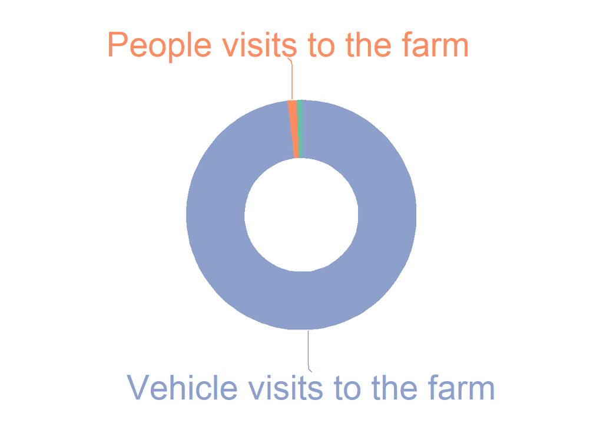

(a) IBR

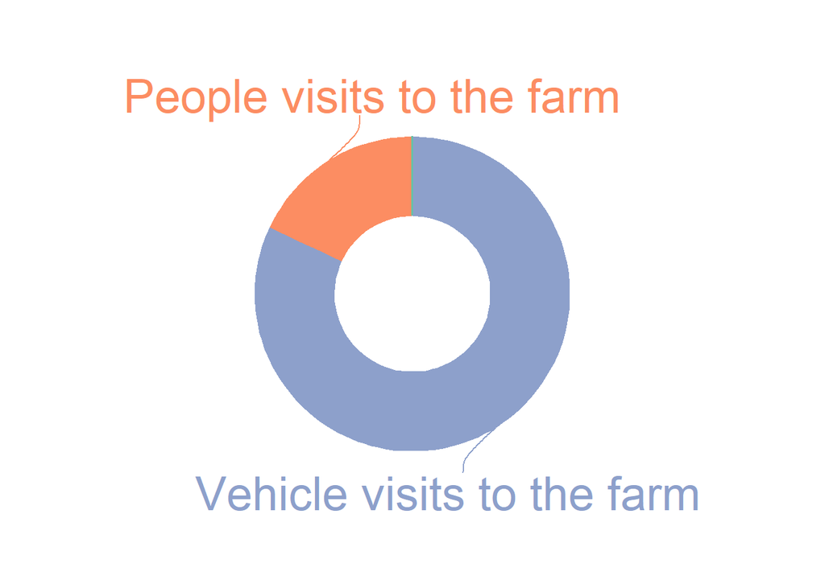

(b) BVD

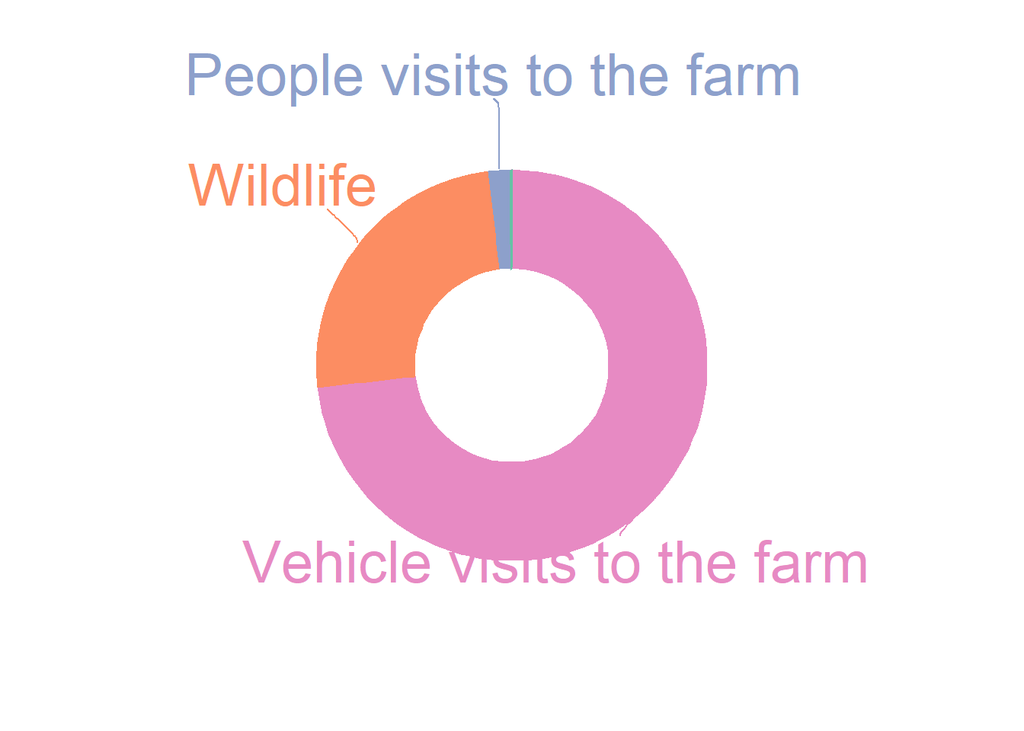

(c) TB

Figure 1.2: Risk of disease entry by pathway

## **Infectious Bovine Rhinotracheitis (IBR)**

### Current risk

Annual risk of IBR entry in the farm: **1.4%** (0.657-2.86%)

By pathway:

- Vehicle visits to the farm: **1.37%** (0.628-2.83%)
- People visits to the farm: **0.0182%** (0.00642-0.0343%)
- Neigbouring farms: **0.00825%** (0.000333-0.0265%)

### Risk reduction of biosecurity measures

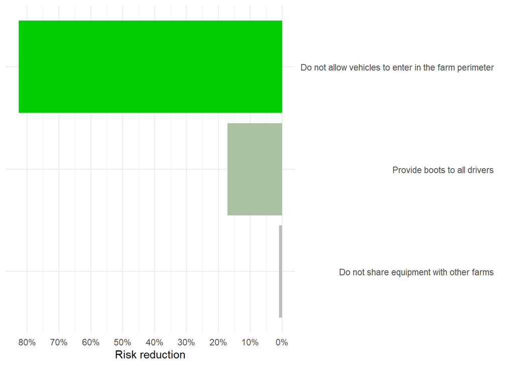

## **Bovine viral diarrhea (BVD)**

### Current risk

Annual risk of BVD entry in the farm: **0.392%** (0.203-0.77%)

By pathway:

- Vehicle visits to the farm: **0.318%** (0.131-0.682%)
- People visits to the farm: **0.0698%** (0.0215-0.157%)
- Neigbouring farms: **2.31e-10%** (8.22e-13-3.8e-09%)

### Risk reduction of biosecurity measures

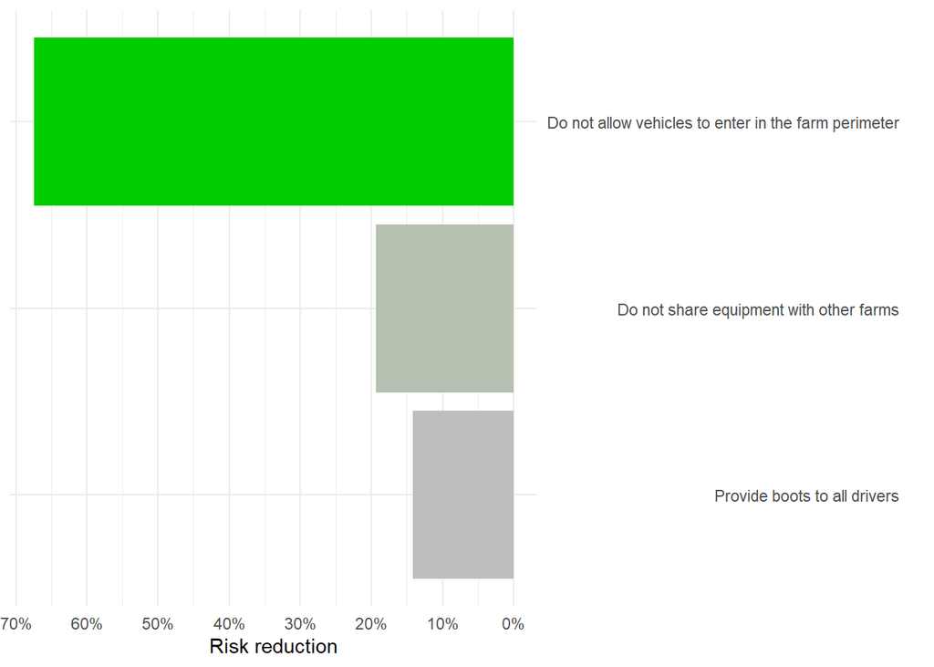

## **Bovine Tuberculosis (TB)**

### Current risk

Annual risk of TB entry in the farm: **0.00155%** (0.000372-0.00554%)

By pathway:

- Vehicle visits to the farm: **0.00101%** (0.000158-0.00468%)
- Wildlife: **0.000342%** (3.61e-05-0.00176%)
- People visits to the farm: **2.47e-05%** (3.11e-06-0.00011%)
- Neigbouring farms: **1.48e-06%** (1.12e-09-3.66e-05%)

### Risk reduction of biosecurity measures

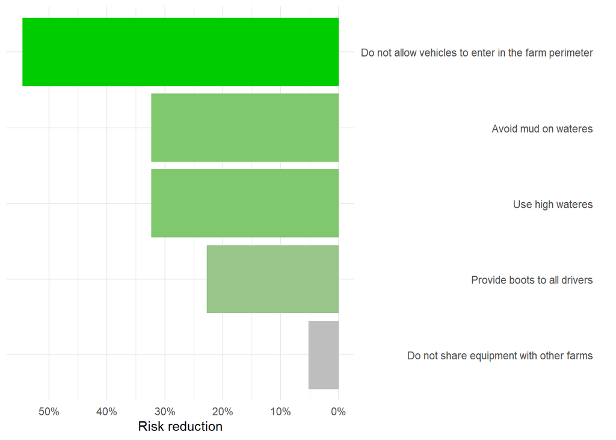

# 🐄 Description of the farm

## Farm information

**Location:** Cataluña, Spain

**Farm type:** Dairy cattle, NA

**Cattle cens:**

- 100 Calves ( <8 m)
- 200 Heifers (8 - 24 m)
- 238 Adult cows (>24 m)
- 6 Bulls

**Other animals in the farm:**

- **Direct contact with cattle:** 2 horses, 10 cats
- **No direct contact with cattle:** 2 dogs

**Neighbours**: 2 cattle farms within a 1-2km radious, no direct contact (IBR: 0.00825%, BVD: 2.31e-10%, TB: 1.48e-06%)

## Farm vehicles

| veh_id | Size | Shared | Cleaning |
| --- | --- | --- | --- |
| Remolquito (c) | 5m2 | No | From time to time |
| Remolque verde (f) | 15m2 | No | From time to time |

## Visits

### People entering the barn

| Visit | Type | Frequency | Boots | Equipment | Risk |
| --- | --- | --- | --- | --- | --- |
| Podòleg | Other animal professionals (e.g. hoof trimmer) | 12 | Never used in other farms | Always used in other farms, always cleaned and disinfected | IBR: 0.00947%, BVD: 0.0324%, TB: 9.08e-06% |
| Veterinari reproduccó | External veterinarians | 12 | Never used in other farms | Always used in other farms, always cleaned and disinfected | IBR: 0.00657%, BVD: 0.0256%, TB: 6.97e-06% |
| Veterinari sanejament | External veterinarians | 2 | Never used in other farms | Always used in other farms, always cleaned and disinfected | IBR: 0.00114%, BVD: 0.00425%, TB: 1.13e-06% |
| Control de plagues | Other professionals (e.g. electrician, plumber…) | 3 | Never used in other farms | Always used in other farms, always cleaned and disinfected | IBR: 0%, BVD: 0%, TB: 0% |

### Vehicles entering the farm perimeter

| Visit | Type | Frequency | Driver | Risk |
| --- | --- | --- | --- | --- |
| Escorxador vaques | Slaughterhouse vehicle | 12 | Enters areas used by farm animals (no contact with animals), boots always used in other farms, unk cleaned and disinfected | IBR: 0.407%, BVD: 0.0942%, TB: 0.00027% |
| Concentrat i gra | Feed vehicle | 1400 | - | IBR: 0.315%, BVD: 0.0639%, TB: 2.33e-05% |
| Escorxador vedelles | Slaughterhouse vehicle (own and not shared) | 6 | - | IBR: 0.195%, BVD: 0.0472%, TB: 0.000139% |
| Escorxador vedelles | Slaughterhouse vehicle | 6 | Enters areas used by farm animals (no contact with animals), boots always used in other farms, unk cleaned and disinfected | IBR: 0.195%, BVD: 0.0472%, TB: 0.000139% |
| Camió per vida | Adult cattle transport vehicle | 12 | Enters areas used by farm animals (no contact with animals), boots sometimes used in other farms, sometimes cleaned and disinfected | IBR: 0.108%, BVD: 0.023%, TB: 6.87e-05% |
| Unifeed compartit | Feed vehicle | 365 | - | IBR: 0.0887%, BVD: 0.0182%, TB: 5.38e-06% |
| Llet | Milk collection vehicle | 365 | - | IBR: 0.0625%, BVD: 0.0117%, TB: 3.71e-06% |
| Cadàvers | Rendering vehicle | 12 | - | IBR: 0.00399%, BVD: 0.000795%, TB: 2.65e-07% |
| Purins | Rendering vehicle | 2 | - | IBR: 0.000671%, BVD: 0.000138%, TB: 4.4e-08% |

# 🚚 Movements

Animal movements in the last 12 months

*No movements in selected period*

### Health status and tests in origin

### Quarantine

#### Characteristics

*No quarantine*

# 🐗 Wildlife

**Wildlife:** IBR: -, BVD: -, TB: 0.000342%

- Outdoors grazing: Outdoors grazing, no complete perimeter fence (simple, electric) (IBR: -, BVD: -, TB: 0.000342%)
- Pasture (trashumance): No pastures

### Farm water points

| Waterpoints | Mud |
| --- | --- |
| 100% Low waterer (<90cm) | 100% |
| 100% River | 100% |
| 100% Low waterer (<90cm) | 0% |

### Pasture water points

*No pasture water points*

# Comments

- Pienso 4 veces día y engorda sus propios terneros, tiene 200 en total y 15 under 2 (complete)

# Technical Annex

- Simulation date: 2025-11-18 12:15:13
- Script unification date: 2025-11-17 12:20:43
- Repository: https://github.com/NataliaCiria/biosecurity_model.git
- Last commit: 5b482c75a9928a4d9b1dd0f39f59ed7d93bb09e0
- Last commit date: 2025-11-16 17:22:55
- user_id:
- farm_id: bl5_v2_mod
- Risk timeframe: 360 days
- Calculate all summaries: FALSE
- Automatic what-if scenarios: TRUE
- Analyse model sensitivity: FALSE
- Farm biosecurity survey: bsg_cattle_v4_1_ciria 2014-09-25
- No movements